# Homework #3: Ames Housing Data

40 points - Due 2/21 at 5:00pm

*Situation*: Can we predict the selling price of a house in Ames, Iowa based on recorded features of the house? That is your task for this assignment. Each group will have a dataset with information on forty potential predictors and the selling price (in $1,000’s) for a sample of homes. The data set for your group is in AmesTrain??.csv (where ?? corresponds to your group number) and can be found in the AmesTrain zipped file under class 14 in Sakai. A separate file identifies the variables in the Ames Housing data and explains some of the coding.

*Directions*: You will be assigned to a group of three to four students for this assignment. Parts 1, 2, & 5 should be turned in individually to Gradescope by each student in your group. Parts 3 & 4 should be submitted as a group to Gradescope. There are separate places to submit the individual and group portions of the assignment.

```r
library(readr)
library(car)
```

```r
library(carData)
library(corrplot)
```

```r
library(leaps)

AmesTrain15 <- read_csv('AmesTrain15.csv')
source("https://raw.githubusercontent.com/JA-McLean/STOR455/master/scripts/ShowSubsets.R")
```

# Part 1. Build an initial “basic” model

mod1: the linear relationship is overall good. The P value of some predictors are large, which are not good for being predictors or because of multicollinearity. The VIF of some variables are lager than 5.

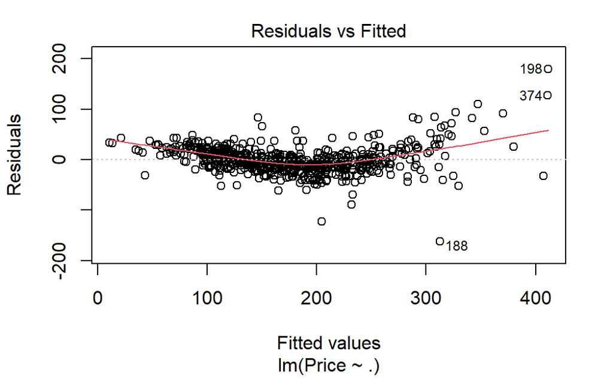

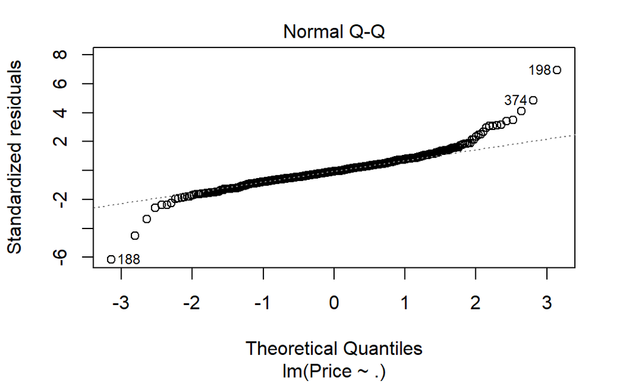

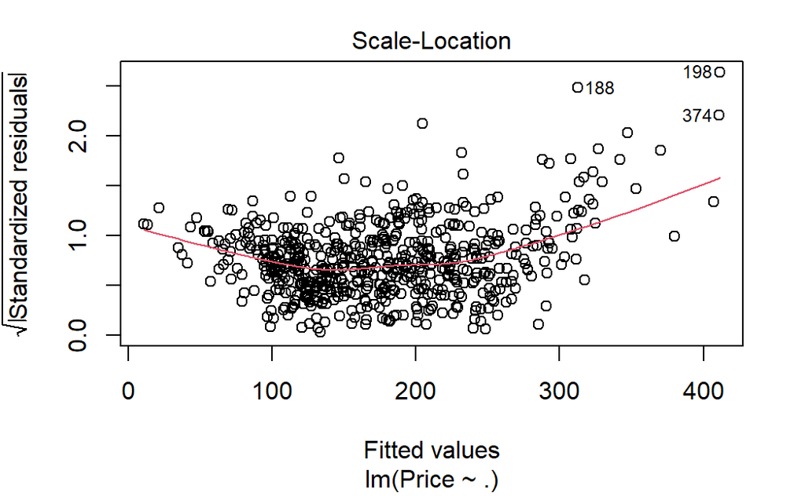

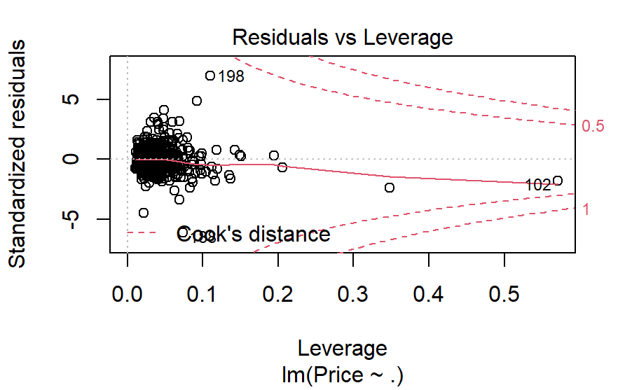

```r
library(dplyr)
#remove the categorical variables
newdata=select_if(AmesTrain15,is.numeric)
#remove the Order variable and predictors that are exactly related
newdata1=subset(newdata,select =-c(Order,BasementSF,GroundSF))

mod1 = lm(Price~., data=newdata1)
plot(mod1)
```

```r
summary(mod1)
```

```
Call:
lm(formula = Price ~ ., data = newdata1)

Residuals:
     Min       1Q   Median       3Q      Max
-162.465  -14.700   -1.206   12.526  180.199

Coefficients:
                  Estimate Std. Error t value Pr(>|t|)
(Intercept)     -1.450e+03  1.696e+02  -8.548  < 2e-16 ***
LotFrontage      1.011e-01  3.777e-02   2.678 0.007617 **
LotArea          7.212e-04  1.049e-04   6.878 1.59e-11 ***
Quality          1.334e+01  1.366e+00   9.763  < 2e-16 ***
Condition        4.400e+00  1.216e+00   3.618 0.000323 ***
YearBuilt        4.126e-01  6.975e-02   5.916 5.67e-09 ***
YearRemodel      2.819e-01  8.239e-02   3.421 0.000667 ***
BasementFinSF    3.224e-02  5.369e-03   6.005 3.39e-09 ***
BasementUnFinSF  1.443e-02  4.768e-03   3.027 0.002583 **
FirstSF          6.450e-02  7.666e-03   8.413 3.16e-16 ***
SecondSF         4.927e-02  6.224e-03   7.917 1.26e-14 ***
BasementFBath    3.569e+00  3.178e+00   1.123 0.261892
BasementHBath   -3.492e-01  5.200e+00  -0.067 0.946488
FullBath         1.304e+00  3.303e+00   0.395 0.693112
HalfBath         3.150e+00  3.328e+00   0.947 0.344271
Bedroom         -4.010e+00  2.225e+00  -1.802 0.071996 .
TotalRooms       1.211e+00  1.492e+00   0.812 0.417213
Fireplaces       3.797e+00  2.211e+00   1.717 0.086499 .
GarageCars       7.756e-01  3.603e+00   0.215 0.829629
GarageSF         3.485e-02  1.193e-02   2.922 0.003619 **
WoodDeckSF       6.779e-03  8.982e-03   0.755 0.450737
OpenPorchSF      2.357e-02  1.992e-02   1.183 0.237152
EnclosedPorchSF  4.911e-02  2.249e-02   2.184 0.029382 *
ScreenPorchSF    6.079e-02  1.808e-02   3.363 0.000822 ***
---
Signif. codes:  0 ‘***’ 0.001 ‘**’ 0.01 ‘*’ 0.05 ‘.’ 0.1 ‘ ’ 1

Residual standard error: 27.48 on 576 degrees of freedom
Multiple R-squared:  0.8642,    Adjusted R-squared:  0.8588
F-statistic: 159.4 on 23 and 576 DF,  p-value: < 2.2e-16
```

```r
vif(mod1)
```

```
    LotFrontage         LotArea         Quality
       1.138633        1.153816        2.831580
      Condition       YearBuilt     YearRemodel
       1.483626        3.755010        2.410622
  BasementFinSF BasementUnFinSF         FirstSF
       3.843505        3.669310        5.364219
       SecondSF   BasementFBath   BasementHBath
       5.686039        2.153095        1.196368
       FullBath        HalfBath         Bedroom
       2.667441        2.249405        2.355825
     TotalRooms      Fireplaces      GarageCars
       4.046101        1.506368        6.328314
       GarageSF      WoodDeckSF     OpenPorchSF
       5.530520        1.138736        1.320660
EnclosedPorchSF   ScreenPorchSF
       1.302683        1.118973
```

## backward method

```r
MSE = (summary(mod1)$sigma)^2
backward_mod = step(mod1, scale=MSE,trace=FALSE)
summary(backward_mod)
```

[output not shown]

## stepwise method

Both of the backward and stepwise methods have the same adjusted R square. Compared with mod1, the model improves from 0.8588 to 0.8595. The predictor of ‘Bedroom’ and ‘Fireplaces’ have p values greater than 0.05, which are not significant at a 5% level. There is no multicollinearity, all VIF is smaller than 5. I choose it as my basic model.

```r
none = lm(Price~1, data=newdata1)
stepwise_mod = step(none, scope=list(upper=mod1), scale=MSE,trace=FALSE)
summary(stepwise_mod)
```

```
Call:
lm(formula = Price ~ Quality + FirstSF + SecondSF + YearBuilt +
    BasementFinSF + GarageSF + LotArea + YearRemodel + Condition +
    ScreenPorchSF + LotFrontage + BasementUnFinSF + EnclosedPorchSF +
    Bedroom + Fireplaces, data = newdata1)

Residuals:
     Min       1Q   Median       3Q      Max
-163.707  -15.529   -1.181   12.460  182.143

Coefficients:
                  Estimate Std. Error t value Pr(>|t|)
(Intercept)     -1.541e+03  1.478e+02 -10.426  < 2e-16 ***
Quality          1.338e+01  1.356e+00   9.865  < 2e-16 ***
FirstSF          7.081e-02  6.676e-03  10.607  < 2e-16 ***
SecondSF         5.619e-02  4.373e-03  12.850  < 2e-16 ***
YearBuilt        4.340e-01  6.360e-02   6.824 2.22e-11 ***
BasementFinSF    3.397e-02  5.025e-03   6.760 3.34e-11 ***
GarageSF         3.602e-02  6.895e-03   5.223 2.45e-07 ***
LotArea          7.098e-04  1.034e-04   6.862 1.74e-11 ***
YearRemodel      3.087e-01  7.794e-02   3.961 8.37e-05 ***
Condition        4.302e+00  1.188e+00   3.622 0.000318 ***
ScreenPorchSF    5.883e-02  1.782e-02   3.302 0.001017 **
LotFrontage      1.049e-01  3.711e-02   2.828 0.004851 **
BasementUnFinSF  1.311e-02  4.612e-03   2.843 0.004632 **
EnclosedPorchSF  5.098e-02  2.238e-02   2.278 0.023064 *
Bedroom         -3.549e+00  1.942e+00  -1.827 0.068144 .
Fireplaces       3.934e+00  2.182e+00   1.803 0.071897 .
---
Signif. codes:
0 ‘***’ 0.001 ‘**’ 0.01 ‘*’ 0.05 ‘.’ 0.1 ‘ ’ 1

Residual standard error: 27.42 on 584 degrees of freedom
Multiple R-squared:  0.863, Adjusted R-squared:  0.8595
F-statistic: 245.2 on 15 and 584 DF,  p-value: < 2.2e-16
```

```r
vif(stepwise_mod)
```

```
        Quality         FirstSF        SecondSF
       2.803892        4.085771        2.819819
      YearBuilt   BasementFinSF        GarageSF
       3.136790        3.382215        1.856329
        LotArea     YearRemodel       Condition
       1.127769        2.166455        1.421239
  ScreenPorchSF     LotFrontage BasementUnFinSF
       1.091640        1.104353        3.449046
EnclosedPorchSF         Bedroom      Fireplaces
       1.295556        1.803771        1.473448
```

# Part 2: Residual analysis

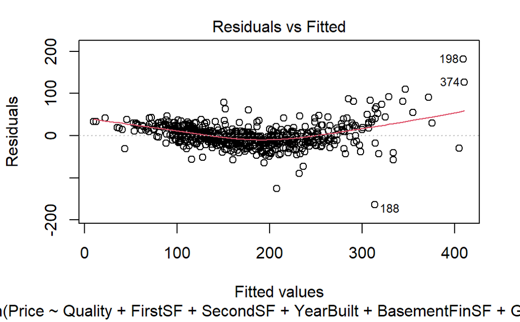

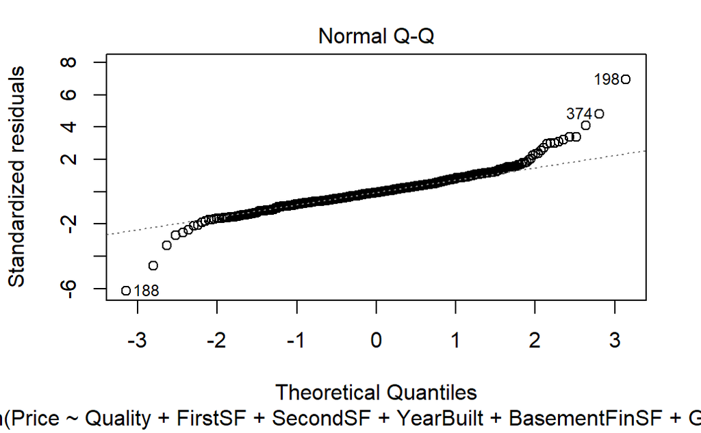

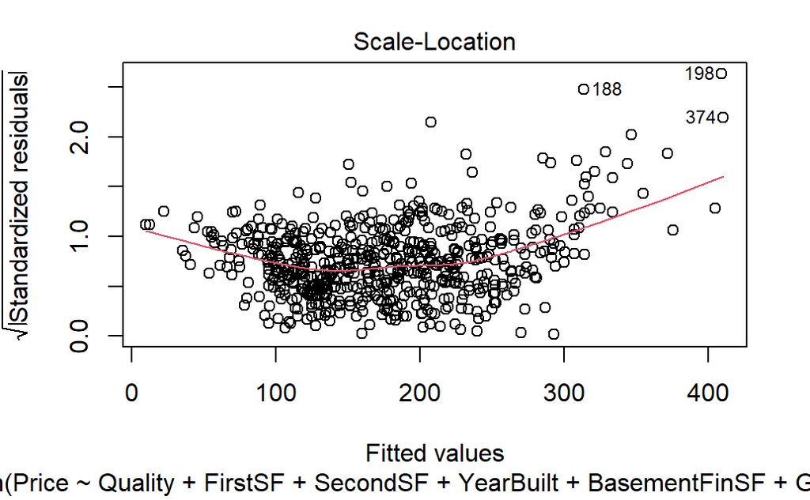

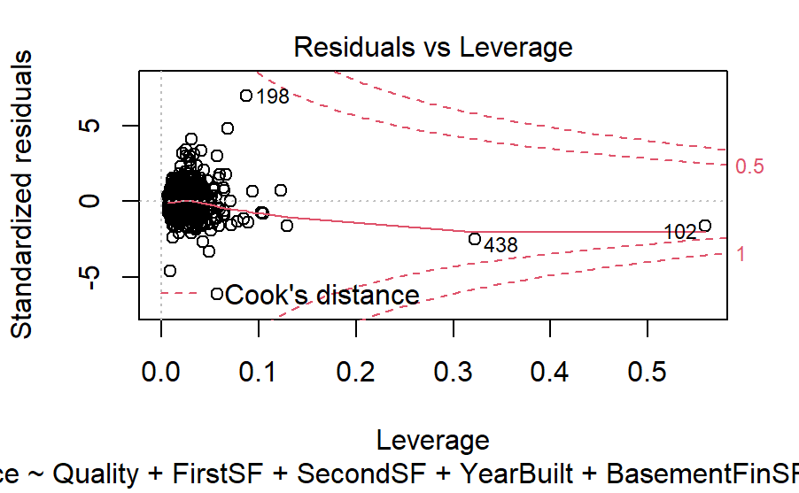

```r
plot(stepwise_mod)
```

```r
head(sort(abs(rstudent(stepwise_mod)), decreasing=TRUE), 15)
```

```
     198      188      374      204       62       70
7.257870 6.355659 4.909422 4.681470 4.146571 3.437666
     581      268      202      537      535      386
3.397817 3.370246 3.226921 3.116382 3.043575 3.012107
     572      228      203
2.993612 2.748336 2.717243
```

```r
head(sort(cooks.distance(stepwise_mod), decreasing=TRUE), n=5)
```

```
      198       102       438       188       374
0.2915410 0.2152589 0.1902544 0.1449232 0.1070727
```

```r
adjustmod = lm(formula = Price ~ Quality + FirstSF + SecondSF + YearBuilt +
    BasementFinSF + GarageSF + LotArea + YearRemodel + Condition +
    ScreenPorchSF + LotFrontage + BasementUnFinSF + EnclosedPorchSF, data = newdata1)
summary(adjustmod)
```

```
Call:
lm(formula = Price ~ Quality + FirstSF + SecondSF + YearBuilt +
    BasementFinSF + GarageSF + LotArea + YearRemodel + Condition +
    ScreenPorchSF + LotFrontage + BasementUnFinSF + EnclosedPorchSF,
    data = newdata1)

Residuals:
     Min       1Q   Median       3Q      Max
-161.815  -15.967   -2.116   12.778  179.683

Coefficients:
                  Estimate Std. Error t value Pr(>|t|)
(Intercept)     -1.559e+03  1.468e+02 -10.613  < 2e-16 ***
Quality          1.406e+01  1.337e+00  10.516  < 2e-16 ***
FirstSF          6.954e-02  6.018e-03  11.555  < 2e-16 ***
SecondSF         5.281e-02  3.326e-03  15.878  < 2e-16 ***
YearBuilt        4.321e-01  6.355e-02   6.799 2.60e-11 ***
BasementFinSF    3.441e-02  5.038e-03   6.830 2.13e-11 ***
GarageSF         3.875e-02  6.795e-03   5.702 1.87e-08 ***
LotArea          7.254e-04  1.034e-04   7.017 6.28e-12 ***
YearRemodel      3.143e-01  7.645e-02   4.111 4.51e-05 ***
Condition        4.323e+00  1.182e+00   3.657 0.000278 ***
ScreenPorchSF    6.340e-02  1.779e-02   3.564 0.000394 ***
LotFrontage      1.002e-01  3.720e-02   2.693 0.007277 **
BasementUnFinSF  1.149e-02  4.585e-03   2.507 0.012442 *
EnclosedPorchSF  5.577e-02  2.239e-02   2.490 0.013041 *
---
Signif. codes:
0 ‘***’ 0.001 ‘**’ 0.01 ‘*’ 0.05 ‘.’ 0.1 ‘ ’ 1

Residual standard error: 27.53 on 586 degrees of freedom
Multiple R-squared:  0.8613,    Adjusted R-squared:  0.8582
F-statistic: 279.9 on 13 and 586 DF,  p-value: < 2.2e-16
```

# Part 3 & 4: Group work

# Part 5: Final model

(The fancier final model is put in group work.) A 95% prediction interval for the Price of this house is (228.7178, 348.0183).

```r
newHouse=data.frame(LotFrontage=400,
LotArea=21540,
Quality=7,
Condition=5,
YearBuilt=1983,
YearRemodel=1999,
BasementUnFinSF=757,
BasementFinSF=0,
BasementSF=757,
FirstSF=1485,
SecondSF=947,
BasementFBath=0,
Bedroom=4,
Fireplaces=1,
GarageCars=2,
GarageSF=588,
EnclosedPorchSF=0,
ScreenPorchSF=0)

predict.lm(stepwise_mod, newHouse, interval="prediction")
```

[output not shown]

3.2 class 22 cross validation

```r
set.seed(12345)
rows <- sample(nrow(newdata1))
Price_shuffled = newdata1[rows,]

PriceTrain=Price_shuffled[1:480,]
PriceHoldout=Price_shuffled[481:600,]
```

```r
fitprice=predict(stepwise_mod,newdata=PriceHoldout)
fitprice
holdoutresid=PriceHoldout$Price - fitprice
holdoutresid
```

[output not shown]

```r
mean(holdoutresid)
mean(stepwise_mod$resid)

sd(holdoutresid)
summary(stepwise_mod)$sigma

qqnorm(holdoutresid)
qqline(holdoutresid)
plot(stepwise_mod,2)
```

[output not shown]

```r
crosscorr=cor(PriceHoldout$Price,fitprice)
crosscorr
crosscorr=cor(PriceHoldout$Price,fitprice)^2
shrinkage = summary(stepwise_mod)$r.squared-crosscorr^2
shrinkage
```

[output not shown]